# Создание проектов

# Цель

После написания кода приложения необходимо уметь:

- компилировать файлы с исходным кодом
- линковать их с библиотеками
- распространять их как (source/binary)
- запускать тесты

# Компиляция

Как компилировать?

- gcc c a.out main.cpp

# Компиляция

А теперь представим:

- проект содержит несколько тысяч файлов
- некоторые файлы должны компилироваться только на некоторых ОС
- для разных заказчиков вы должны собирать проект:
  - с разными define (DEBUG/RELEASE, LOG)
  - для разных ОС
  - для разных компиляторов
  - ...

# Линковка и другие аспекты

- Линковка
- Распространение приложений
  - .rpm, .msi, .dmg, .exe, InstallShield, .tar.gz, .zip, .7z, ...
- Тестирование

# История

- shell скрипты

compile.sh:

```
#!/bin/sh
cc -c main.c
cc -c lib.c
cc -o program main.o lib.o
```

- make, 1977 год

Makefile:

```
OBJ = main.o lib.o
program: $(OBJ)
        cc -o program $(OBJ)
$(OBJ): defines.h
```

# Autotools

Makefile.am:

```
bin_PROGRAMS = hello
hello_SOURCES = main.c lib.c
```

configure.ac:

```
AC_INIT([program], [1.0], [sample@mail.org])
AM_INIT_AUTOMAKE([-Wall -Werror foreign])
AC_PROG_CC
AC_CONFIG_HEADERS([config.h])
AC_CONFIG_FILES([
 Makefile
])
AC_OUTPUT
```

Для запуска:

```
autoreconf --install
./configure
make
```

# Autotools

Было де-факто стандартом и до сих пор используется, но:

- слишком сложно
- только Unix
- sh, m4
- зависимости

# CMake

[figure not shown]

- Cmake
- CPack
- CTest + BullsEye/gcov
- CDash

# CMake

CMakeLists.txt

cmake / CMakeSetup / CMakeGui

=> .vcproj / Makefile / etc

Visual Studio, Eclipse, KDevelop, XCode, ...

=> .obj / .o

linker (link.exe, ld, ...)

=> .exe / .dll / .lib / .a / .so / .dylib

# Где хранятся объектные и бинарные файлы

В директории с исходным кодом:

- src/hello.cpp
- src/hello.exe

Вне ее:

- src/hello.cpp
- build/hello.exe

# Пример сборки

CMakeLists.txt:

```
cmake_minimum_required(VERSION 2.8)
project(first_sample)

set(SOURCES main.c lib.c)
add_executable(main ${SOURCES})
```

Для запуска:

```
mkdir ../build
cd ../build
cmake ../code/
make
```

# Debug/Release

- `SET(CMAKE_BUILD_TYPE Debug)`
- `$ cmake DCMAKE_BUILD_TYPE=Release ../src`

Для библиотек:

- `TARGET_LINK_LIBRARIES(lib RELEASE ${lib_SRCS})`
- `TARGET_LINK_LIBRARIES(libd DEBUG ${lib_SRCS})`

# Пример сборки библиотеки

CMakeLists.txt:

```
cmake_minimum_required(VERSION 2.8)
project(second_sample)

set(SOURCE_LIB lib.c)
add_library(library STATIC ${SOURCE_LIB})

set(SOURCES main.c)
add_executable(main ${SOURCES})
target_link_libraries(main library)
```

# Добавление подпроекта

Содержимое каталога:

```
  - main.c
  - library
    - lib.c
    - lib.h
    - CMakeLists.txt
  - CMakeLists.txt
```

CMakeLists.txt:

```
cmake_minimum_required(VERSION 2.8)
project(third_sample)

set(SOURCES main.c)
include_directories(library)
add_executable(main ${SOURCES})

add_subdirectory(library)
target_link_libraries(main library)
```

# Добавление подпроекта

library/CMakeLists.txt:

```
cmake_minimum_required(VERSION 2.8)
project(library)

set(SOURCE_LIB lib.c)
add_library(library STATIC ${SOURCE_LIB})
```

# Поиск библиотек

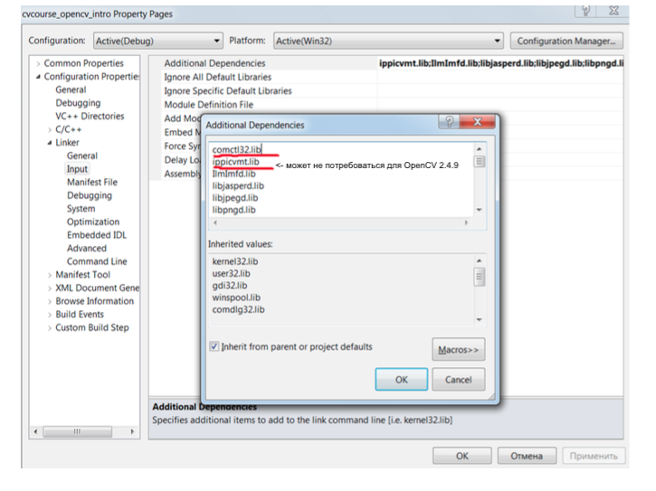

# Поиск библиотек

CMakeLists.txt:

```
cmake_minimum_required(VERSION 2.8)
project(sample)

find_package(OPENCV REQUIRED)
if(NOT OPENCV_FOUND)
    message(SEND_ERROR "Failed to find OpenCV")
    return()
else()
    include_directories(${OPENCV_INCLUDE_DIR})
endif()

add_executable(sample main.c)
target_link_libraries(sample ${OPENCV_LIBRARIES})
```

# Билд-системы

Популярные билд-системы:

- [SCons](http://www.scons.org)
  - [Waf](https://code.google.com/p/waf/)
- [Rake](https://github.com/ruby/rake)
- [Makeit](https://bitbucket.org/grahamdumpleton/makeit)
- [Jam](http://www.perforce.com/resources/documentation/jam)
- [qmake](http://en.wikipedia.org/wiki/Qmake)
- [Maven](http://maven.apache.org/)

# Резюме

1. Использование современных IDE может существенно облегчить процесс разработки.
2. Метапрограммирование позволяет динамически создавать однотипный код.
3. Билд-системы - незаменимый инструмент при разработке кроссплатформенных приложений.

# Контрольные вопросы

1. Определение ИСР
2. Отличия ИСР от редакторов исходного кода
3. Основные функции/возможности современных ИСР
4. Определение метапрограммирования и его примеры
5. Иcтория развития билд-систем
6. Плюсы и минусы Makefile
7. Плюсы и минусы CMake

# Ссылки

1. http://ru.wikipedia.org/wiki/Сравнение_IDE
2. http://rus-linux.net/lib.php?name=/MyLDP/algol/lex-yacc-howto.html
3. http://www.scons.org/wiki/SconsVsOtherBuildTools

# Спасибо!

Вопросы?